# MortgageStateLevel

### Loading Modules & Libraries

```python
import pandas as pd
import numpy as np
import cufflinks as cf
import plotly as py
import plotly.graph_objs as go
import ipywidgets as widgets
from scipy import special
import matplotlib.pyplot as plt
import seaborn as sns
import math
from IPython.display import Markdown, display ,HTML
import statsmodels.api as sm # import API
from matplotlib.pyplot import xticks
sns.set(style="whitegrid")
pd.set_option('display.max_columns', 100)
py.offline.init_notebook_mode(connected=True) # plotting in offilne mode
cf.set_config_file(offline=False, world_readable=True, theme='ggplot')
pd.set_option('display.max_colwidth', None) # make sure data and columns are displayed correctly without purge
pd.options.display.float_format = '{:20,.2f}'.format # display float value with correct precision
import warnings
warnings.filterwarnings('ignore')
%matplotlib inline
```

### Meta Data Helper Utilities

```python
def log(string):
    display(Markdown("> <span style='color:blue'>"+string+"</span>"))
```

```python
def header(string):
    display(Markdown("------ "))
    display(Markdown("### "+string))
```

```python
def header_red(string):
    display(Markdown("> <span style='color:red'>"+string))
```

```python
def color_red(val):
    color = 'red' if val > 65 else 'black'
    return 'color: %s' % color
```

```python
def get_variable_type(element) :
    if element==0:
        return "Not Known"
    elif element >2 and element < 20:
        return "Categorical"
    elif element >= 20 and element!=0 :
        return "Contineous"
```

```python
def predict_variable_type(metadata_matrix):
    metadata_matrix["Variable_Type"] = metadata_matrix["Unique_Values_Count"].apply(get_variable_type).astype(str)
    metadata_matrix["frequency"] = metadata_matrix["Null_Count"] - metadata_matrix["Null_Count"]
    metadata_matrix["frequency"].astype(int)
    return metadata_matrix
```

```python
def get_meta_data(dataframe) :
    metadata_matrix = pd.DataFrame({
                    'Datatype' : dataframe.dtypes.astype(str),
                    'Non_Null_Count': dataframe.count(axis = 0).astype(int),
                    'Null_Count': dataframe.isnull().sum().astype(int),
                    'Null_Percentage': dataframe.isnull().sum()/len(dataframe) * 100,
                    'Unique_Values_Count': dataframe.nunique().astype(int)
                     })
    metadata_matrix = predict_variable_type(metadata_matrix)
    return metadata_matrix
```

```python
def display_columns_with_1_unique_value(dataframe):
    unique_values_count_1 = dataframe[dataframe["Unique_Values_Count"] == 1]
    drop_value_col = unique_values_count_1.index.tolist()
    lenght = len(drop_value_col)
    header("Columns with only one unique value : "+str(lenght))
    if lenght == 0 :
        header_red("No columns with only one unique values.")
    else :
        for index,item in enumerate(drop_value_col) :
            print(index,".",item)
```

```python
def list_potential_categorical_type(dataframe,main) :
    header("Stats for potential Categorical datatype columns")
    metadata_matrix_categorical = dataframe[dataframe["Variable_Type"] == "Categorical"]
    # TO DO *** Add check to skip below if there is no Categorical values
    length = len(metadata_matrix_categorical)
    if length == 0 :
        header_red("No Categorical columns in given dataset.")
    else:
        metadata_matrix_categorical = metadata_matrix_categorical.filter(["Datatype","Unique_Values_Count"])
        metadata_matrix_categorical.sort_values(["Unique_Values_Count"], axis=0,ascending=False, inplace=True)
        col_to_check = metadata_matrix_categorical.index.tolist()
        name_list = []
        values_list = []
        for name in col_to_check :
            name_list.append(name)
            values_list.append(main[name].unique())
        temp = pd.DataFrame({"index":name_list,"Unique_Values":values_list})
        metadata_matrix_categorical = metadata_matrix_categorical.reset_index()
        metadata_matrix_categorical = pd.merge(metadata_matrix_categorical,temp,how='inner',on='index')
        display(metadata_matrix_categorical.set_index("index"))
```

```python
def get_potential_categorical_type(dataframe,main,unique_count) :
    metadata_matrix_categorical = dataframe[dataframe["Variable_Type"] == "Categorical"]
    metadata_matrix_categorical = dataframe[dataframe["Unique_Values_Count"] == unique_count]
    length = len(metadata_matrix_categorical)
    if length == 0 :
        header_red("No Categorical columns in given dataset.")
    else :
        metadata_matrix_categorical = metadata_matrix_categorical.filter(["Datatype","Unique_Values_Count"])
        metadata_matrix_categorical.sort_values(["Unique_Values_Count"], axis=0,ascending=False, inplace=True)
        col_to_check = metadata_matrix_categorical.index.tolist()
        name_list = []
        values_list = []
        for name in col_to_check :
            name_list.append(name)
            values_list.append(main[name].unique())
        temp = pd.DataFrame({"index":name_list,"Unique_Values":values_list})
        metadata_matrix_categorical = metadata_matrix_categorical.reset_index()
        metadata_matrix_categorical = pd.merge(metadata_matrix_categorical,temp,how='inner',on='index')
        display(metadata_matrix_categorical.set_index("index"))
```

```python
def plot_data_type_pie_chat(dataframe) :
    header("Stats for Datatype Percentage Distribution")
    dataframe_group = dataframe.groupby("Datatype").frequency.count().reset_index()
    dataframe_group.sort_values(["Datatype"], axis=0,ascending=False, inplace=True)
    trace = go.Pie(labels=dataframe_group["Datatype"].tolist(), values=dataframe_group["frequency"].tolist())
    layout = go.Layout(title="Datatype Percentage Distribution")
    fig = go.Figure(data=[trace], layout=layout)
    py.offline.iplot(fig)
```

```python
def pairplot(x_axis,y_axis) :
    sns.pairplot(df,x_vars=x_axis,y_vars=y_axis,height=4,aspect=1,kind="scatter")
    plt.show()
```

```python
def heatmap(x,y,dataframe):
    plt.figure(figsize=(x,y))
    sns.heatmap(dataframe.corr(),cmap="OrRd",annot=True)
    plt.show()
```

```python
def plot_box_chart(dataframe) :
    data = []
    for index, column_name in enumerate(dataframe) :
        data.append(
        go.Box(y=dataframe.iloc[:, index],name=column_name))

    layout = go.Layout(yaxis=dict(title="Frequency",zeroline=False),boxmode='group')
    fig = go.Figure(data=data, layout=layout)
    py.offline.iplot(fig)
```

```python
def bar_count_plot(dataframe,col_name) :
    plt.figure(figsize=(16,8))
    plt.title(col_name + 'Histogram')
    sns.countplot(df[col_name], palette=("plasma"))
    xticks(rotation = 90)
    plt.show()
```

```python
def color_red(val):
    color = 'red' if val > 5 else 'black'
    return 'color: %s' % color
```

```python
def color_code_vif_values(val):
    if val > 10 : color = 'red'
    elif val > 5 and val <= 10 : color = 'blue'
    elif val > 0 and val <= 5 : color = 'darkgreen'
    else : color = 'black'
    return 'color: %s' % color
```

```python
def drop_col(dataframe,col_to_drop) :
    dataframe.drop([col_to_drop],axis=1,inplace=True)
    return dataframe
```

## Loading the dataset

```python
df_train = pd.read_csv("train.csv")
df_train['Data Type']='Train'
df_test = pd.read_csv("test.csv")
df_test['Data Type']='Test'
df=pd.concat([df_train,df_test])
del df['UID']
display(df.head())
print("Dimension of the Data: ",df.shape)
```

|  | BLOCKID | SUMLEVEL | COUNTYID | STATEID | state | state_ab | city | place | type | primary | zip_code | area_code | lat | lng | ALand | AWater | pop | male_pop | female_pop | rent_mean | rent_median | rent_stdev | rent_sample_weight | rent_samples | rent_gt_10 | rent_gt_15 | rent_gt_20 | rent_gt_25 | rent_gt_30 | … |
| --- | --- | --- | --- | --- | --- | --- | --- | --- | --- | --- | --- | --- | --- | --- | --- | --- | --- | --- | --- | --- | --- | --- | --- | --- | --- | --- | --- | --- | --- | --- |
| 0 | nan | 140 | 53 | 36 | New York | NY | Hamilton | Hamilton | City | tract | 13346 | 315 | 42.84 | -75.50 | 202,183,361.00 | 1699120 | 5230 | 2612 | 2618 | 769.39 | 784.00 | 232.64 | 272.34 | 362.00 | 0.87 | 0.79 | 0.59 | 0.46 | 0.43 | … |
| 1 | nan | 140 | 141 | 18 | Indiana | IN | South Bend | Roseland | City | tract | 46616 | 574 | 41.70 | -86.27 | 1,560,828.00 | 100363 | 2633 | 1349 | 1284 | 804.88 | 848.00 | 253.47 | 312.59 | 513.00 | 0.97 | 0.93 | 0.70 | 0.70 | 0.55 | … |
| 2 | nan | 140 | 63 | 18 | Indiana | IN | Danville | Danville | City | tract | 46122 | 317 | 39.79 | -86.52 | 69,561,595.00 | 284193 | 6881 | 3643 | 3238 | 742.77 | 703.00 | 323.39 | 291.86 | 378.00 | 0.95 | 0.89 | 0.80 | 0.67 | 0.39 | … |
| 3 | nan | 140 | 127 | 72 | Puerto Rico | PR | San Juan | Guaynabo | Urban | tract | 927 | 787 | 18.40 | -66.10 | 1,105,793.00 | 0 | 2700 | 1141 | 1559 | 803.42 | 782.00 | 297.39 | 259.30 | 368.00 | 0.95 | 0.87 | 0.70 | 0.62 | 0.51 | … |
| 4 | nan | 140 | 161 | 20 | Kansas | KS | Manhattan | Manhattan City | City | tract | 66502 | 785 | 39.20 | -96.57 | 2,554,403.00 | 0 | 5637 | 2586 | 3051 | 938.56 | 881.00 | 392.44 | 1,005.43 | 1,704.00 | 0.99 | 0.98 | 0.92 | 0.85 | 0.78 | … |

```
Dimension of the Data:  (39030, 80)
```

```python
df.info()
```

```
<class 'pandas.core.frame.DataFrame'>
Int64Index: 39030 entries, 0 to 11708
Data columns (total 80 columns):
 #   Column                       Non-Null Count  Dtype
---  ------                       --------------  -----
 0   BLOCKID                      0 non-null      float64
 1   SUMLEVEL                     39030 non-null  int64
 2   COUNTYID                     39030 non-null  int64
 3   STATEID                      39030 non-null  int64
 4   state                        39030 non-null  object
 5   state_ab                     39030 non-null  object
 6   city                         39030 non-null  object
 7   place                        39030 non-null  object
 8   type                         39030 non-null  object
 9   primary                      39030 non-null  object
```

[output cut: 72 more lines]

```python
del df['BLOCKID']
log('Dropping Varable BLOCKID (contains all Null)')
```

> Dropping Varable BLOCKID (contains all Null)

## Meta data analysis for loaded dataset

```python
metadata_matrix_dataframe = get_meta_data(df)

# 1. Columns List with only 1 unique values
display_columns_with_1_unique_value(metadata_matrix_dataframe)

# 2. Display Data Type percenatges
plot_data_type_pie_chat(metadata_matrix_dataframe)

# 3. Potential Categorical Variable columns
list_potential_categorical_type(metadata_matrix_dataframe,df)
```

Columns with only one unique value : 2

```
0 . SUMLEVEL
1 . primary
```

Stats for Datatype Percentage Distribution

[interactive chart not shown]

Stats for potential Categorical datatype columns

| index | Datatype | Unique_Values_Count | Unique_Values |
| --- | --- | --- | --- |
| type | object | 6 | [City, Urban, Town, CDP, Village, Borough] |

```python
del df['SUMLEVEL']
del df['primary']
```

> Dropping Varable with unique values

# Understanding the Data

```python
df.head()
```

|  | COUNTYID | STATEID | state | state_ab | city | place | type | zip_code | area_code | lat | lng | ALand | AWater | pop | male_pop | female_pop | rent_mean | rent_median | rent_stdev | rent_sample_weight | rent_samples | rent_gt_10 | rent_gt_15 | rent_gt_20 | rent_gt_25 | rent_gt_30 | rent_gt_35 | rent_gt_40 | rent_gt_50 | … |
| --- | --- | --- | --- | --- | --- | --- | --- | --- | --- | --- | --- | --- | --- | --- | --- | --- | --- | --- | --- | --- | --- | --- | --- | --- | --- | --- | --- | --- | --- | --- |
| 0 | 53 | 36 | New York | NY | Hamilton | Hamilton | City | 13346 | 315 | 42.84 | -75.50 | 202,183,361.00 | 1699120 | 5230 | 2612 | 2618 | 769.39 | 784.00 | 232.64 | 272.34 | 362.00 | 0.87 | 0.79 | 0.59 | 0.46 | 0.43 | 0.19 | 0.15 | 0.13 | … |
| 1 | 141 | 18 | Indiana | IN | South Bend | Roseland | City | 46616 | 574 | 41.70 | -86.27 | 1,560,828.00 | 100363 | 2633 | 1349 | 1284 | 804.88 | 848.00 | 253.47 | 312.59 | 513.00 | 0.97 | 0.93 | 0.70 | 0.70 | 0.55 | 0.41 | 0.39 | 0.28 | … |
| 2 | 63 | 18 | Indiana | IN | Danville | Danville | City | 46122 | 317 | 39.79 | -86.52 | 69,561,595.00 | 284193 | 6881 | 3643 | 3238 | 742.77 | 703.00 | 323.39 | 291.86 | 378.00 | 0.95 | 0.89 | 0.80 | 0.67 | 0.39 | 0.39 | 0.28 | 0.16 | … |
| 3 | 127 | 72 | Puerto Rico | PR | San Juan | Guaynabo | Urban | 927 | 787 | 18.40 | -66.10 | 1,105,793.00 | 0 | 2700 | 1141 | 1559 | 803.42 | 782.00 | 297.39 | 259.30 | 368.00 | 0.95 | 0.87 | 0.70 | 0.62 | 0.51 | 0.47 | 0.36 | 0.33 | … |
| 4 | 161 | 20 | Kansas | KS | Manhattan | Manhattan City | City | 66502 | 785 | 39.20 | -96.57 | 2,554,403.00 | 0 | 5637 | 2586 | 3051 | 938.56 | 881.00 | 392.44 | 1,005.43 | 1,704.00 | 0.99 | 0.98 | 0.92 | 0.85 | 0.78 | 0.61 | 0.55 | 0.44 | … |

### Null value treatment

```python
df=df[df['hc_mortgage_mean'].notna()]

df=df.sort_values(by=['lat','lng'])

df=df.fillna(method="ffill")
display(df.head())
```

|  | COUNTYID | STATEID | state | state_ab | city | place | type | zip_code | area_code | lat | lng | ALand | AWater | pop | male_pop | female_pop | rent_mean | rent_median | rent_stdev | rent_sample_weight | rent_samples | rent_gt_10 | rent_gt_15 | rent_gt_20 | rent_gt_25 | rent_gt_30 | rent_gt_35 | rent_gt_40 | rent_gt_50 | … |
| --- | --- | --- | --- | --- | --- | --- | --- | --- | --- | --- | --- | --- | --- | --- | --- | --- | --- | --- | --- | --- | --- | --- | --- | --- | --- | --- | --- | --- | --- | --- |
| 2651 | 123 | 72 | Puerto Rico | PR | Salinas | Central Aguirre | Urban | 751 | 787 | 17.93 | -66.24 | 21,091,150.00 | 27780143 | 4497 | 2231 | 2266 | 451.78 | 401.00 | 157.60 | 180.92 | 189.00 | 1.00 | 0.83 | 0.83 | 0.66 | 0.59 | 0.59 | 0.59 | 0.50 | … |
| 22814 | 133 | 72 | Puerto Rico | PR | Santa Isabel | Jauca | Urban | 757 | 787 | 17.96 | -66.38 | 22,913,790.00 | 18678307 | 6201 | 3267 | 2934 | 657.34 | 440.00 | 459.46 | 221.92 | 304.00 | 0.88 | 0.84 | 0.68 | 0.50 | 0.41 | 0.41 | 0.41 | 0.41 | … |
| 3615 | 55 | 72 | Puerto Rico | PR | Guanica | Guánica | Urban | 653 | 787 | 17.96 | -66.94 | 24,698,929.00 | 7594540 | 2786 | 1367 | 1419 | 435.37 | 457.00 | 52.11 | 46.00 | 46.00 | 1.00 | 1.00 | 1.00 | 1.00 | 1.00 | 0.65 | 0.26 | 0.26 | … |
| 23737 | 57 | 72 | Puerto Rico | PR | Guayama | Jobos | Urban | 784 | 787 | 17.96 | -66.17 | 6,493,321.00 | 6066 | 2840 | 1230 | 1610 | 548.76 | 537.00 | 149.29 | 144.00 | 144.00 | 1.00 | 1.00 | 0.88 | 0.88 | 0.88 | 0.88 | 0.88 | 0.82 | … |
| 258 | 113 | 72 | Puerto Rico | PR | Ponce | Ponce | Urban | 731 | 787 | 17.97 | -66.61 | 3,946,834.00 | 5093745 | 4688 | 2211 | 2477 | 739.91 | 773.00 | 186.38 | 299.30 | 375.00 | 1.00 | 1.00 | 0.91 | 0.91 | 0.77 | 0.77 | 0.77 | 0.77 | … |

> Filling the missing values with the nearest location value.

### Dummy Variables

```python
def create_dummy_variable(dataframe,column_name):
    dummy_values = pd.get_dummies(dataframe[column_name],drop_first=True)
    dataframe = pd.concat([dataframe,dummy_values],axis=1)
    dataframe.drop([column_name],axis=1,inplace=True)
    return dataframe
```

```python
df.head()
```

|  | COUNTYID | STATEID | state | state_ab | city | place | type | zip_code | area_code | lat | lng | ALand | AWater | pop | male_pop | female_pop | rent_mean | rent_median | rent_stdev | rent_sample_weight | rent_samples | rent_gt_10 | rent_gt_15 | rent_gt_20 | rent_gt_25 | rent_gt_30 | rent_gt_35 | rent_gt_40 | rent_gt_50 | … |
| --- | --- | --- | --- | --- | --- | --- | --- | --- | --- | --- | --- | --- | --- | --- | --- | --- | --- | --- | --- | --- | --- | --- | --- | --- | --- | --- | --- | --- | --- | --- |
| 2651 | 123 | 72 | Puerto Rico | PR | Salinas | Central Aguirre | Urban | 751 | 787 | 17.93 | -66.24 | 21,091,150.00 | 27780143 | 4497 | 2231 | 2266 | 451.78 | 401.00 | 157.60 | 180.92 | 189.00 | 1.00 | 0.83 | 0.83 | 0.66 | 0.59 | 0.59 | 0.59 | 0.50 | … |
| 22814 | 133 | 72 | Puerto Rico | PR | Santa Isabel | Jauca | Urban | 757 | 787 | 17.96 | -66.38 | 22,913,790.00 | 18678307 | 6201 | 3267 | 2934 | 657.34 | 440.00 | 459.46 | 221.92 | 304.00 | 0.88 | 0.84 | 0.68 | 0.50 | 0.41 | 0.41 | 0.41 | 0.41 | … |
| 3615 | 55 | 72 | Puerto Rico | PR | Guanica | Guánica | Urban | 653 | 787 | 17.96 | -66.94 | 24,698,929.00 | 7594540 | 2786 | 1367 | 1419 | 435.37 | 457.00 | 52.11 | 46.00 | 46.00 | 1.00 | 1.00 | 1.00 | 1.00 | 1.00 | 0.65 | 0.26 | 0.26 | … |
| 23737 | 57 | 72 | Puerto Rico | PR | Guayama | Jobos | Urban | 784 | 787 | 17.96 | -66.17 | 6,493,321.00 | 6066 | 2840 | 1230 | 1610 | 548.76 | 537.00 | 149.29 | 144.00 | 144.00 | 1.00 | 1.00 | 0.88 | 0.88 | 0.88 | 0.88 | 0.88 | 0.82 | … |
| 258 | 113 | 72 | Puerto Rico | PR | Ponce | Ponce | Urban | 731 | 787 | 17.97 | -66.61 | 3,946,834.00 | 5093745 | 4688 | 2211 | 2477 | 739.91 | 773.00 | 186.38 | 299.30 | 375.00 | 1.00 | 1.00 | 0.91 | 0.91 | 0.77 | 0.77 | 0.77 | 0.77 | … |

#### Creating dummy variables

```python
df = create_dummy_variable(df,"type")
df = create_dummy_variable(df,"state_ab")
```

> Converting type to dummies

```python
display(df.describe())
```

|  | COUNTYID | STATEID | zip_code | area_code | lat | lng | ALand | AWater | pop | male_pop | female_pop | rent_mean | rent_median | rent_stdev | rent_sample_weight | rent_samples | rent_gt_10 | rent_gt_15 | rent_gt_20 | rent_gt_25 | rent_gt_30 | rent_gt_35 | rent_gt_40 | rent_gt_50 | universe_samples | used_samples | hi_mean | hi_median | hi_stdev | … |
| --- | --- | --- | --- | --- | --- | --- | --- | --- | --- | --- | --- | --- | --- | --- | --- | --- | --- | --- | --- | --- | --- | --- | --- | --- | --- | --- | --- | --- | --- | --- |
| count | 38,189.00 | 38,189.00 | 38,189.00 | 38,189.00 | 38,189.00 | 38,189.00 | 38,189.00 | 38,189.00 | 38,189.00 | 38,189.00 | 38,189.00 | 38,189.00 | 38,189.00 | 38,189.00 | 38,189.00 | 38,189.00 | 38,189.00 | 38,189.00 | 38,189.00 | 38,189.00 | 38,189.00 | 38,189.00 | 38,189.00 | 38,189.00 | 38,189.00 | 38,189.00 | 38,189.00 | 38,189.00 | 38,189.00 | … |
| mean | 85.64 | 28.31 | 50,160.88 | 595.35 | 37.51 | -91.32 | 124,419,162.98 | 6,105,699.91 | 4,378.02 | 2,150.18 | 2,227.84 | 1,054.37 | 1,006.91 | 394.88 | 296.57 | 549.15 | 0.96 | 0.87 | 0.74 | 0.61 | 0.50 | 0.41 | 0.35 | 0.25 | 581.13 | 534.96 | 70,601.26 | 57,704.23 | 54,604.30 | … |
| std | 98.34 | 16.44 | 29,576.53 | 232.35 | 5.58 | 16.31 | 1,155,112,928.63 | 202,977,294.56 | 2,084.81 | 1,046.75 | 1,071.74 | 434.38 | 440.59 | 187.49 | 269.15 | 455.33 | 0.06 | 0.11 | 0.14 | 0.16 | 0.16 | 0.16 | 0.15 | 0.14 | 457.38 | 443.76 | 30,124.60 | 29,132.41 | 17,483.66 | … |
| min | 1.00 | 1.00 | 601.00 | 201.00 | 17.93 | -166.77 | 8,299.00 | 0.00 | 4.00 | 0.00 | 0.00 | 159.13 | 107.00 | 18.26 | 0.34 | 3.00 | 0.00 | 0.00 | 0.00 | 0.00 | 0.00 | 0.00 | 0.00 | 0.00 | 0.00 | 0.00 | 4,999.85 | 4,790.00 | 1,825.74 | … |
| 25% | 29.00 | 13.00 | 26,801.00 | 405.00 | 33.92 | -97.82 | 1,809,262.00 | 0.00 | 2,949.00 | 1,434.00 | 1,493.00 | 743.11 | 703.00 | 263.80 | 103.06 | 223.00 | 0.94 | 0.82 | 0.66 | 0.52 | 0.40 | 0.31 | 0.24 | 0.16 | 258.00 | 217.00 | 49,298.09 | 37,485.00 | 42,226.52 | … |
| 50% | 63.00 | 28.00 | 47,802.00 | 614.00 | 38.73 | -86.63 | 4,916,599.00 | 26,759.00 | 4,100.00 | 2,001.00 | 2,086.00 | 952.64 | 897.00 | 347.55 | 222.46 | 429.00 | 0.98 | 0.89 | 0.76 | 0.62 | 0.50 | 0.41 | 0.34 | 0.24 | 464.00 | 418.00 | 64,142.20 | 51,360.00 | 52,309.92 | … |
| 75% | 109.00 | 42.00 | 77,304.00 | 801.00 | 41.36 | -79.83 | 34,140,943.00 | 519,220.00 | 5,463.00 | 2,681.00 | 2,786.00 | 1,259.21 | 1,196.00 | 475.74 | 410.88 | 745.00 | 1.00 | 0.94 | 0.84 | 0.72 | 0.61 | 0.52 | 0.44 | 0.34 | 778.00 | 726.00 | 85,897.57 | 70,839.00 | 65,340.09 | … |
| max | 840.00 | 72.00 | 99,929.00 | 989.00 | 67.07 | -65.38 | 103,951,000,000.00 | 24,532,276,414.00 | 53,812.00 | 26,562.00 | 27,250.00 | 3,962.34 | 3,972.00 | 1,720.72 | 4,112.12 | 7,634.00 | 1.00 | 1.00 | 1.00 | 1.00 | 1.00 | 1.00 | 1.00 | 1.00 | 7,634.00 | 7,336.00 | 228,588.21 | 253,857.00 | 124,534.01 | … |

8 rows × 127 columns

```python
del_cols=['state','STATEID','COUNTYID','zip_code','area_code','place','city']
for col in del_cols:
    del df[col]
display(df.head())
log("Deleting the unnecessary and repetitive variables")
print("Total columns left for model fitting: ",len(df.columns)-1)
```

|  | lat | lng | ALand | AWater | pop | male_pop | female_pop | rent_mean | rent_median | rent_stdev | rent_sample_weight | rent_samples | rent_gt_10 | rent_gt_15 | rent_gt_20 | rent_gt_25 | rent_gt_30 | rent_gt_35 | rent_gt_40 | rent_gt_50 | universe_samples | used_samples | hi_mean | hi_median | hi_stdev | hi_sample_weight | hi_samples | family_mean | family_median | … |
| --- | --- | --- | --- | --- | --- | --- | --- | --- | --- | --- | --- | --- | --- | --- | --- | --- | --- | --- | --- | --- | --- | --- | --- | --- | --- | --- | --- | --- | --- | --- |
| 2651 | 17.93 | -66.24 | 21,091,150.00 | 27780143 | 4497 | 2231 | 2266 | 451.78 | 401.00 | 157.60 | 180.92 | 189.00 | 1.00 | 0.83 | 0.83 | 0.66 | 0.59 | 0.59 | 0.59 | 0.50 | 324 | 189 | 21,238.86 | 14,300.00 | 20,427.89 | 1,413.28 | 1,722.00 | 25,980.13 | 19,076.00 | … |
| 22814 | 17.96 | -66.38 | 22,913,790.00 | 18678307 | 6201 | 3267 | 2934 | 657.34 | 440.00 | 459.46 | 221.92 | 304.00 | 0.88 | 0.84 | 0.68 | 0.50 | 0.41 | 0.41 | 0.41 | 0.41 | 344 | 304 | 31,721.21 | 18,982.00 | 34,182.36 | 1,423.37 | 1,897.00 | 37,454.97 | 34,110.00 | … |
| 3615 | 17.96 | -66.94 | 24,698,929.00 | 7594540 | 2786 | 1367 | 1419 | 435.37 | 457.00 | 52.11 | 46.00 | 46.00 | 1.00 | 1.00 | 1.00 | 1.00 | 1.00 | 0.65 | 0.26 | 0.26 | 164 | 46 | 17,458.22 | 13,496.00 | 15,792.34 | 765.39 | 897.00 | 20,711.01 | 16,244.00 | … |
| 23737 | 17.96 | -66.17 | 6,493,321.00 | 6066 | 2840 | 1230 | 1610 | 548.76 | 537.00 | 149.29 | 144.00 | 144.00 | 1.00 | 1.00 | 0.88 | 0.88 | 0.88 | 0.88 | 0.88 | 0.82 | 179 | 144 | 22,322.66 | 15,990.00 | 20,251.40 | 838.52 | 1,018.00 | 25,903.79 | 16,988.00 | … |
| 258 | 17.97 | -66.61 | 3,946,834.00 | 5093745 | 4688 | 2211 | 2477 | 739.91 | 773.00 | 186.38 | 299.30 | 375.00 | 1.00 | 1.00 | 0.91 | 0.91 | 0.77 | 0.77 | 0.77 | 0.77 | 546 | 319 | 32,024.03 | 23,941.00 | 39,369.65 | 1,527.39 | 1,876.00 | 40,845.84 | 31,971.00 | … |

5 rows × 124 columns

> Deleting the unnecessary and repetitive variables

```
Total columns left for model fitting:  123
```

# Preparing Train and Test data

```python
np.random.seed(0)
df_train=df[df['Data Type']=='Train']
del df_train['Data Type']
df_test=df[df['Data Type']=='Test']
del df_test['Data Type']
```

> Segregation of test and train dataset

```python
print('Shape of Train dataset: ',df_train.shape)
print('Shape of Test dataset: ',df_test.shape)
```

```
Shape of Train dataset:  (26748, 123)
Shape of Test dataset:  (11441, 123)
```

# Model Building Approach

### We shall be using mixed approach to find the relevent features.

1. Variance Inflation factor
2. Backward p-value elimination

### Dividing the dependent and independent variables for the model building

```python
y_train = df_train.pop('hc_mortgage_mean')
x_train = df_train

y_test = df_test.pop('hc_mortgage_mean')
x_test = df_test
```

#### Initial model for feature selection

```python
from sklearn.linear_model import LinearRegression
model = LinearRegression()
model.fit(x_train, y_train)
```

```
LinearRegression()
```

```python
print("R2 test: ",model.score(x_test, y_test))

print("R2 train: ",model.score(x_train, y_train))
```

```
R2 test:  0.9874594692765637
R2 train:  0.988069247978753
```

> The scores are high but the model will be unstable.

### Feature Selection

```python
model_count = 0
from statsmodels.stats.outliers_influence import variance_inflation_factor
#Stats Model Summary
def statsmodel_summary(y_var,x_var) :
    global model_count
    model_count = model_count + 1
    text = "MODEL - " + str(model_count)
    header(text)
    x_var_const = sm.add_constant(x_var) # adding constant
    lm = sm.OLS(y_var,x_var_const).fit() # calculating the fit
    print(lm.summary()) # print summary for analysis
    #display_vif(x_var_const.drop(['const'],axis=1))
    return x_var_const , lm

#Displaying the VIF scores for each features
def display_vif(x) :
    vif = pd.DataFrame()
    X = x
    vif['Features'] = X.columns
    vif['VIF'] = [variance_inflation_factor(X.values, i) for i in range(X.shape[1])]
    vif['VIF'] = round(vif['VIF'], 2)
    vif = vif.set_index("Features")
    vif = vif.sort_values(by = "VIF", ascending = False)
    df = pd.DataFrame(vif.VIF).style.applymap(color_code_vif_values)
    display(df)

#Calculating and reccursively deleting the features with high VIFs greater than a threshold
def calculate_vif_(X, thresh=7.5):
    variables = list(range(X.shape[1]))
    dropped = True
    while dropped:
        dropped = False
        vif = [variance_inflation_factor(X.iloc[:, variables].values, ix)
               for ix in range(X.iloc[:, variables].shape[1])]

        maxloc = vif.index(max(vif))
        if max(vif) > thresh:
            print('dropping \'' + X.iloc[:, variables].columns[maxloc] +
                  '\' at index: ' + str(maxloc))
            del variables[maxloc]
            dropped = True

    print('Remaining variables:')
    print(X.columns[variables])
    return X.iloc[:, variables]
```

#### Keeping only the important columns

```python
col=calculate_vif_(x_train).columns
```

```
dropping 'pop' at index: 4
dropping 'female_pop' at index: 5
dropping 'NH' at index: 98
dropping 'OH' at index: 102
dropping 'DE' at index: 76
dropping 'Urban' at index: 67
dropping 'male_pop' at index: 4
dropping 'City' at index: 64
dropping 'hi_samples' at index: 23
dropping 'hs_degree' at index: 44
dropping 'used_samples' at index: 18
dropping 'hi_mean' at index: 18
dropping 'universe_samples' at index: 17
dropping 'Town' at index: 59
dropping 'lng' at index: 1
dropping 'female_age_mean' at index: 47
dropping 'male_age_mean' at index: 42
dropping 'family_mean' at index: 19
dropping 'lat' at index: 0
dropping 'family_samples' at index: 21
dropping 'rent_gt_10' at index: 7
dropping 'female_age_samples' at index: 45
dropping 'hs_degree_female' at index: 37
dropping 'male_age_stdev' at index: 38
dropping 'hc_mean' at index: 24
dropping 'rent_mean' at index: 2
dropping 'hi_stdev' at index: 14
dropping 'debt' at index: 29
dropping 'hi_sample_weight' at index: 14
dropping 'male_age_samples' at index: 34
dropping 'female_age_stdev' at index: 35
dropping 'rent_gt_15' at index: 6
dropping 'hs_degree_male' at index: 30
dropping 'male_age_median' at index: 30
dropping 'rent_gt_25' at index: 7
dropping 'hc_samples' at index: 21
dropping 'family_median' at index: 12
dropping 'rent_gt_35' at index: 8
dropping 'pct_own' at index: 29
dropping 'female_age_median' at index: 27
```

[output cut: 15 more lines]

```
dropping 'second_mortgage' at index: 11
dropping 'rent_median' at index: 2
dropping 'debt_cdf' at index: 12
dropping 'rent_samples' at index: 4
dropping 'hc_stdev' at index: 6
Remaining variables:
Index(['ALand', 'AWater', 'rent_stdev', 'rent_sample_weight', 'rent_gt_50',
       'hc_mortgage_samples', 'hc_sample_weight',
       'home_equity_second_mortgage', 'home_equity', 'second_mortgage_cdf',
       'married_snp', 'separated', 'divorced', 'Village', 'AL', 'AR', 'AZ',
       'CA', 'CO', 'CT', 'DC', 'FL', 'GA', 'HI', 'IA', 'ID', 'IL', 'IN', 'KS',
       'KY', 'LA', 'MA', 'MD', 'ME', 'MI', 'MN', 'MO', 'MS', 'MT', 'NC', 'ND',
       'NE', 'NJ', 'NM', 'NV', 'NY', 'OK', 'OR', 'PA', 'PR', 'RI', 'SC', 'SD',
       'TN', 'TX', 'UT', 'VA', 'VT', 'WA', 'WI', 'WV', 'WY'],
      dtype='object')
```

> Keeping only the important columns for VIF less than 7.5

# Model building and appropriate features selection

```python
x_new = x_train[col]
x_new,lm_new = statsmodel_summary(y_train,x_new)
```

MODEL - 1

```
                            OLS Regression Results
==============================================================================
Dep. Variable:       hc_mortgage_mean   R-squared:                       0.673
Model:                            OLS   Adj. R-squared:                  0.672
Method:                 Least Squares   F-statistic:                     885.9
Date:                Tue, 20 Jul 2021   Prob (F-statistic):               0.00
Time:                        17:44:36   Log-Likelihood:            -1.9512e+05
No. Observations:               26748   AIC:                         3.904e+05
Df Residuals:                   26685   BIC:                         3.909e+05
Df Model:                          62
Covariance Type:            nonrobust
===============================================================================================
                                  coef    std err          t      P>|t|      [0.025      0.975]
-----------------------------------------------------------------------------------------------
const                        1466.5245     26.820     54.679      0.000    1413.955    1519.094
ALand                       -4.777e-09   1.91e-09     -2.507      0.012   -8.51e-09   -1.04e-09
AWater                      -4.443e-09    1.1e-08     -0.405      0.685   -2.59e-08     1.7e-08
rent_stdev                      1.1231      0.014     80.704      0.000       1.096       1.150
rent_sample_weight             -0.1762      0.009    -19.729      0.000      -0.194      -0.159
rent_gt_50                   -262.9762     16.833    -15.622      0.000    -295.971    -229.982
hc_mortgage_samples             0.1131      0.006     18.374      0.000       0.101       0.125
hc_sample_weight               -0.5210      0.015    -35.045      0.000      -0.550      -0.492
home_equity_second_mortgage -1710.8774    104.914    -16.307      0.000   -1916.515   -1505.239
home_equity                  2186.8056     45.570     47.987      0.000    2097.485    2276.126
second_mortgage_cdf            -4.0017     10.937     -0.366      0.714     -25.438      17.435
married_snp                    13.2505     88.167      0.150      0.881    -159.561     186.062
separated                   -1895.8163    149.789    -12.657      0.000   -2189.410   -1602.222
divorced                    -1585.4622     51.542    -30.760      0.000   -1686.488   -1484.436
Village                      -336.0340     25.401    -13.229      0.000    -385.822    -286.246
AL                           -229.1444     29.064     -7.884      0.000    -286.111    -172.178
AR                           -206.5789     31.920     -6.472      0.000    -269.143    -144.015
AZ                           -235.9112     27.652     -8.531      0.000    -290.111    -181.711
CA                            219.7863     23.958      9.174      0.000     172.827     266.745
CO                           -173.8404     28.228     -6.158      0.000    -229.169    -118.511
CT                            164.8037     30.363      5.428      0.000     105.291     224.317
DC                            140.4297     49.739      2.823      0.005      42.939     237.920
FL                            -90.5218     24.662     -3.670      0.000    -138.861     -42.182
GA                           -196.1337     26.335     -7.448      0.000    -247.751    -144.516
HI                            287.5018     40.178      7.156      0.000     208.751     366.253
IA                           -367.1702     31.161    -11.783      0.000    -428.248    -306.092
```

[output cut: 33 more lines]

```
WA                            -52.9204     27.541     -1.922      0.055    -106.901       1.061
WI                           -223.1405     27.656     -8.068      0.000    -277.348    -168.933
WV                           -270.3772     36.125     -7.485      0.000    -341.184    -199.570
WY                            -73.1803     52.539     -1.393      0.164    -176.159      29.798
==============================================================================
Omnibus:                     4222.612   Durbin-Watson:                   1.843
Prob(Omnibus):                  0.000   Jarque-Bera (JB):            15992.250
Skew:                           0.761   Prob(JB):                         0.00
Kurtosis:                       6.469   Cond. No.                     9.66e+10
==============================================================================

Notes:
[1] Standard Errors assume that the covariance matrix of the errors is correctly specified.
[2] The condition number is large, 9.66e+10. This might indicate that there are
strong multicollinearity or other numerical problems.
```

## Backward elimination p-value

#### Removing the features with the highest p-value one at a time

```python
x_new,lm_new = statsmodel_summary(y_train,drop_col(x_new,"married_snp"))
```

MODEL - 2

```
                            OLS Regression Results
==============================================================================
Dep. Variable:       hc_mortgage_mean   R-squared:                       0.673
Model:                            OLS   Adj. R-squared:                  0.672
Method:                 Least Squares   F-statistic:                     900.5
Date:                Tue, 20 Jul 2021   Prob (F-statistic):               0.00
Time:                        17:44:36   Log-Likelihood:            -1.9512e+05
No. Observations:               26748   AIC:                         3.904e+05
Df Residuals:                   26686   BIC:                         3.909e+05
Df Model:                          61
Covariance Type:            nonrobust
===============================================================================================
                                  coef    std err          t      P>|t|      [0.025      0.975]
-----------------------------------------------------------------------------------------------
const                        1466.9592     26.663     55.018      0.000    1414.697    1519.221
ALand                       -4.772e-09   1.91e-09     -2.505      0.012   -8.51e-09   -1.04e-09
AWater                      -4.439e-09    1.1e-08     -0.405      0.686   -2.59e-08     1.7e-08
rent_stdev                      1.1231      0.014     80.709      0.000       1.096       1.150
rent_sample_weight             -0.1760      0.009    -19.855      0.000      -0.193      -0.159
rent_gt_50                   -262.8638     16.816    -15.631      0.000    -295.825    -229.903
hc_mortgage_samples             0.1130      0.006     18.454      0.000       0.101       0.125
hc_sample_weight               -0.5211      0.015    -35.096      0.000      -0.550      -0.492
home_equity_second_mortgage -1709.8271    104.679    -16.334      0.000   -1915.004   -1504.650
home_equity                  2186.3080     45.449     48.105      0.000    2097.225    2275.391
second_mortgage_cdf            -3.9432     10.930     -0.361      0.718     -25.366      17.479
separated                   -1881.5239    115.727    -16.258      0.000   -2108.355   -1654.693
divorced                    -1585.9420     51.442    -30.829      0.000   -1686.772   -1485.112
Village                      -336.1438     25.390    -13.239      0.000    -385.910    -286.378
AL                           -229.1997     29.061     -7.887      0.000    -286.161    -172.239
AR                           -206.7038     31.908     -6.478      0.000    -269.246    -144.162
AZ                           -235.9128     27.652     -8.532      0.000    -290.112    -181.714
CA                            219.8954     23.947      9.183      0.000     172.959     266.832
CO                           -173.8507     28.228     -6.159      0.000    -229.179    -118.523
CT                            164.7648     30.361      5.427      0.000     105.255     224.274
DC                            140.5140     49.735      2.825      0.005      43.032     237.996
FL                            -90.4612     24.659     -3.669      0.000    -138.793     -42.129
GA                           -196.1425     26.334     -7.448      0.000    -247.759    -144.526
HI                            287.7713     40.137      7.170      0.000     209.100     366.442
IA                           -367.3065     31.147    -11.792      0.000    -428.357    -306.256
ID                           -286.3847     42.243     -6.779      0.000    -369.183    -203.586
```

[output cut: 32 more lines]

```
WA                            -52.9495     27.539     -1.923      0.055    -106.928       1.029
WI                           -223.2774     27.641     -8.078      0.000    -277.454    -169.100
WV                           -270.4712     36.119     -7.488      0.000    -341.266    -199.676
WY                            -73.2597     52.535     -1.394      0.163    -176.231      29.712
==============================================================================
Omnibus:                     4222.150   Durbin-Watson:                   1.843
Prob(Omnibus):                  0.000   Jarque-Bera (JB):            15986.667
Skew:                           0.761   Prob(JB):                         0.00
Kurtosis:                       6.468   Cond. No.                     9.44e+10
==============================================================================

Notes:
[1] Standard Errors assume that the covariance matrix of the errors is correctly specified.
[2] The condition number is large, 9.44e+10. This might indicate that there are
strong multicollinearity or other numerical problems.
```

```python
x_new,lm_new = statsmodel_summary(y_train,drop_col(x_new,"second_mortgage_cdf"))
```

MODEL - 3

```
                            OLS Regression Results
==============================================================================
Dep. Variable:       hc_mortgage_mean   R-squared:                       0.673
Model:                            OLS   Adj. R-squared:                  0.672
Method:                 Least Squares   F-statistic:                     915.5
Date:                Tue, 20 Jul 2021   Prob (F-statistic):               0.00
Time:                        17:44:36   Log-Likelihood:            -1.9512e+05
No. Observations:               26748   AIC:                         3.904e+05
Df Residuals:                   26687   BIC:                         3.909e+05
Df Model:                          60
Covariance Type:            nonrobust
===============================================================================================
                                  coef    std err          t      P>|t|      [0.025      0.975]
-----------------------------------------------------------------------------------------------
const                        1464.2790     25.607     57.182      0.000    1414.087    1514.470
ALand                       -4.786e-09    1.9e-09     -2.512      0.012   -8.52e-09   -1.05e-09
AWater                      -4.427e-09    1.1e-08     -0.404      0.686   -2.59e-08    1.71e-08
rent_stdev                      1.1230      0.014     80.709      0.000       1.096       1.150
rent_sample_weight             -0.1763      0.009    -19.992      0.000      -0.194      -0.159
rent_gt_50                   -262.9628     16.814    -15.640      0.000    -295.919    -230.007
hc_mortgage_samples             0.1135      0.006     19.097      0.000       0.102       0.125
hc_sample_weight               -0.5214      0.015    -35.189      0.000      -0.550      -0.492
home_equity_second_mortgage -1687.5585     84.545    -19.961      0.000   -1853.271   -1521.846
home_equity                  2186.7899     45.429     48.137      0.000    2097.747    2275.833
separated                   -1882.7800    115.673    -16.277      0.000   -2109.504   -1656.056
divorced                    -1585.1061     51.389    -30.845      0.000   -1685.832   -1484.380
Village                      -336.0060     25.387    -13.235      0.000    -385.766    -286.246
AL                           -229.1193     29.060     -7.884      0.000    -286.078    -172.161
AR                           -206.7865     31.907     -6.481      0.000    -269.326    -144.247
AZ                           -235.9815     27.651     -8.534      0.000    -290.178    -181.785
CA                            220.0306     23.943      9.190      0.000     173.100     266.961
CO                           -173.7377     28.226     -6.155      0.000    -229.061    -118.414
CT                            164.7925     30.361      5.428      0.000     105.284     224.301
DC                            140.4954     49.734      2.825      0.005      43.015     237.976
FL                            -90.4576     24.658     -3.668      0.000    -138.789     -42.126
GA                           -196.0968     26.334     -7.447      0.000    -247.712    -144.482
HI                            287.8840     40.135      7.173      0.000     209.217     366.551
IA                           -367.0965     31.142    -11.788      0.000    -428.136    -306.057
ID                           -286.1940     42.239     -6.776      0.000    -368.985    -203.403
IL                            274.6299     15.402     17.830      0.000     244.440     304.820
```

[output cut: 31 more lines]

```
WA                            -52.8368     27.537     -1.919      0.055    -106.811       1.138
WI                           -223.0178     27.631     -8.071      0.000    -277.175    -168.860
WV                           -270.5486     36.118     -7.491      0.000    -341.341    -199.756
WY                            -73.0511     52.531     -1.391      0.164    -176.015      29.913
==============================================================================
Omnibus:                     4214.156   Durbin-Watson:                   1.843
Prob(Omnibus):                  0.000   Jarque-Bera (JB):            15941.506
Skew:                           0.760   Prob(JB):                         0.00
Kurtosis:                       6.463   Cond. No.                     9.44e+10
==============================================================================

Notes:
[1] Standard Errors assume that the covariance matrix of the errors is correctly specified.
[2] The condition number is large, 9.44e+10. This might indicate that there are
strong multicollinearity or other numerical problems.
```

```python
x_new,lm_new = statsmodel_summary(y_train,drop_col(x_new,"AWater"))
```

MODEL - 4

```
                            OLS Regression Results
==============================================================================
Dep. Variable:       hc_mortgage_mean   R-squared:                       0.673
Model:                            OLS   Adj. R-squared:                  0.672
Method:                 Least Squares   F-statistic:                     931.1
Date:                Tue, 20 Jul 2021   Prob (F-statistic):               0.00
Time:                        17:44:37   Log-Likelihood:            -1.9512e+05
No. Observations:               26748   AIC:                         3.904e+05
Df Residuals:                   26688   BIC:                         3.909e+05
Df Model:                          59
Covariance Type:            nonrobust
===============================================================================================
                                  coef    std err          t      P>|t|      [0.025      0.975]
-----------------------------------------------------------------------------------------------
const                        1463.1851     25.463     57.463      0.000    1413.276    1513.094
ALand                        -5.09e-09   1.75e-09     -2.910      0.004   -8.52e-09   -1.66e-09
rent_stdev                      1.1229      0.014     80.713      0.000       1.096       1.150
rent_sample_weight             -0.1764      0.009    -19.996      0.000      -0.194      -0.159
rent_gt_50                   -262.9487     16.814    -15.639      0.000    -295.904    -229.993
hc_mortgage_samples             0.1135      0.006     19.098      0.000       0.102       0.125
hc_sample_weight               -0.5214      0.015    -35.187      0.000      -0.550      -0.492
home_equity_second_mortgage -1687.6860     84.543    -19.963      0.000   -1853.394   -1521.978
home_equity                  2186.8468     45.428     48.139      0.000    2097.806    2275.888
separated                   -1882.7417    115.671    -16.277      0.000   -2109.462   -1656.021
divorced                    -1585.1381     51.389    -30.846      0.000   -1685.862   -1484.414
Village                      -334.8897     25.236    -13.271      0.000    -384.353    -285.427
AL                           -227.9955     28.926     -7.882      0.000    -284.691    -171.300
AR                           -205.6447     31.781     -6.471      0.000    -267.937    -143.352
AZ                           -234.8059     27.497     -8.539      0.000    -288.701    -180.911
CA                            221.1654     23.777      9.302      0.000     174.561     267.770
CO                           -172.5466     28.071     -6.147      0.000    -227.566    -117.527
CT                            165.9157     30.232      5.488      0.000     106.658     225.173
DC                            141.6358     49.653      2.853      0.004      44.314     238.958
FL                            -89.3522     24.505     -3.646      0.000    -137.384     -41.320
GA                           -194.9760     26.186     -7.446      0.000    -246.303    -143.649
HI                            289.0096     40.038      7.218      0.000     210.533     367.486
IA                           -365.9438     31.010    -11.801      0.000    -426.725    -305.163
ID                           -284.9007     42.117     -6.765      0.000    -367.452    -202.349
IL                            274.6369     15.402     17.831      0.000     244.448     304.826
IN                           -422.0944     27.246    -15.492      0.000    -475.499    -368.690
```

[output cut: 30 more lines]

```
WA                            -51.7045     27.394     -1.887      0.059    -105.397       1.988
WI                           -221.8999     27.491     -8.072      0.000    -275.784    -168.016
WV                           -269.4200     36.009     -7.482      0.000    -339.999    -198.841
WY                            -71.4651     52.383     -1.364      0.172    -174.139      31.209
==============================================================================
Omnibus:                     4214.164   Durbin-Watson:                   1.843
Prob(Omnibus):                  0.000   Jarque-Bera (JB):            15940.482
Skew:                           0.760   Prob(JB):                         0.00
Kurtosis:                       6.463   Cond. No.                     9.34e+10
==============================================================================

Notes:
[1] Standard Errors assume that the covariance matrix of the errors is correctly specified.
[2] The condition number is large, 9.34e+10. This might indicate that there are
strong multicollinearity or other numerical problems.
```

```python
x_new,lm_new = statsmodel_summary(y_train,drop_col(x_new,"MD"))
```

MODEL - 5

```
                            OLS Regression Results
==============================================================================
Dep. Variable:       hc_mortgage_mean   R-squared:                       0.673
Model:                            OLS   Adj. R-squared:                  0.672
Method:                 Least Squares   F-statistic:                     947.2
Date:                Tue, 20 Jul 2021   Prob (F-statistic):               0.00
Time:                        17:44:37   Log-Likelihood:            -1.9512e+05
No. Observations:               26748   AIC:                         3.904e+05
Df Residuals:                   26689   BIC:                         3.908e+05
Df Model:                          58
Covariance Type:            nonrobust
===============================================================================================
                                  coef    std err          t      P>|t|      [0.025      0.975]
-----------------------------------------------------------------------------------------------
const                        1456.3335     17.560     82.933      0.000    1421.914    1490.753
ALand                       -4.996e-09   1.73e-09     -2.886      0.004   -8.39e-09    -1.6e-09
rent_stdev                      1.1228      0.014     80.725      0.000       1.096       1.150
rent_sample_weight             -0.1763      0.009    -19.993      0.000      -0.194      -0.159
rent_gt_50                   -263.0345     16.812    -15.646      0.000    -295.986    -230.083
hc_mortgage_samples             0.1135      0.006     19.108      0.000       0.102       0.125
hc_sample_weight               -0.5214      0.015    -35.190      0.000      -0.550      -0.492
home_equity_second_mortgage -1688.0215     84.537    -19.968      0.000   -1853.718   -1522.325
home_equity                  2186.2914     45.402     48.154      0.000    2097.300    2275.283
separated                   -1884.7496    115.543    -16.312      0.000   -2111.219   -1658.280
divorced                    -1584.4909     51.358    -30.852      0.000   -1685.156   -1483.826
Village                      -327.9980     17.113    -19.167      0.000    -361.539    -294.457
AL                           -221.1233     22.240     -9.943      0.000    -264.715    -177.531
AR                           -198.8177     25.932     -7.667      0.000    -249.645    -147.991
AZ                           -227.9364     20.354    -11.199      0.000    -267.831    -188.042
CA                            228.1296     14.632     15.591      0.000     199.450     256.809
CO                           -165.6477     21.053     -7.868      0.000    -206.913    -124.383
CT                            172.8598     23.764      7.274      0.000     126.281     219.439
DC                            148.6419     45.933      3.236      0.001      58.611     238.673
FL                            -82.4416     15.957     -5.166      0.000    -113.718     -51.165
GA                           -188.0722     18.453    -10.192      0.000    -224.241    -151.903
HI                            295.9654     35.392      8.363      0.000     226.596     365.335
IA                           -359.0854     24.918    -14.410      0.000    -407.927    -310.244
ID                           -278.1021     37.935     -7.331      0.000    -352.456    -203.748
IL                            274.6600     15.402     17.833      0.000     244.472     304.848
IN                           -415.2321     20.032    -20.728      0.000    -454.497    -375.968
```

[output cut: 29 more lines]

```
WA                            -44.8102     20.153     -2.223      0.026     -84.312      -5.309
WI                           -215.0183     20.317    -10.583      0.000    -254.841    -175.196
WV                           -262.5850     30.956     -8.483      0.000    -323.260    -201.910
WY                            -64.7697     49.186     -1.317      0.188    -161.177      31.637
==============================================================================
Omnibus:                     4212.291   Durbin-Watson:                   1.843
Prob(Omnibus):                  0.000   Jarque-Bera (JB):            15924.781
Skew:                           0.760   Prob(JB):                         0.00
Kurtosis:                       6.461   Cond. No.                     6.91e+10
==============================================================================

Notes:
[1] Standard Errors assume that the covariance matrix of the errors is correctly specified.
[2] The condition number is large, 6.91e+10. This might indicate that there are
strong multicollinearity or other numerical problems.
```

```python
x_new,lm_new = statsmodel_summary(y_train,drop_col(x_new,"RI"))
```

MODEL - 6

```
                            OLS Regression Results
==============================================================================
Dep. Variable:       hc_mortgage_mean   R-squared:                       0.673
Model:                            OLS   Adj. R-squared:                  0.672
Method:                 Least Squares   F-statistic:                     963.8
Date:                Tue, 20 Jul 2021   Prob (F-statistic):               0.00
Time:                        17:44:37   Log-Likelihood:            -1.9512e+05
No. Observations:               26748   AIC:                         3.904e+05
Df Residuals:                   26690   BIC:                         3.908e+05
Df Model:                          57
Covariance Type:            nonrobust
===============================================================================================
                                  coef    std err          t      P>|t|      [0.025      0.975]
-----------------------------------------------------------------------------------------------
const                        1454.0646     17.045     85.308      0.000    1420.656    1487.474
ALand                       -4.966e-09   1.73e-09     -2.871      0.004   -8.36e-09   -1.58e-09
rent_stdev                      1.1229      0.014     80.735      0.000       1.096       1.150
rent_sample_weight             -0.1764      0.009    -20.021      0.000      -0.194      -0.159
rent_gt_50                   -263.0324     16.812    -15.646      0.000    -295.984    -230.081
hc_mortgage_samples             0.1136      0.006     19.115      0.000       0.102       0.125
hc_sample_weight               -0.5214      0.015    -35.191      0.000      -0.550      -0.492
home_equity_second_mortgage -1687.8634     84.535    -19.966      0.000   -1853.556   -1522.170
home_equity                  2185.9952     45.399     48.151      0.000    2097.012    2274.979
separated                   -1883.4697    115.516    -16.305      0.000   -2109.888   -1657.051
divorced                    -1584.4387     51.357    -30.851      0.000   -1685.102   -1483.775
Village                      -325.7157     16.577    -19.649      0.000    -358.207    -293.224
AL                           -218.8683     21.840    -10.021      0.000    -261.677    -176.060
AR                           -196.5548     25.587     -7.682      0.000    -246.707    -146.403
AZ                           -225.6780     19.915    -11.332      0.000    -264.712    -186.644
CA                            230.3758     14.022     16.429      0.000     202.891     257.860
CO                           -163.3965     20.632     -7.920      0.000    -203.836    -122.957
CT                            175.1134     23.391      7.486      0.000     129.266     220.961
DC                            150.8965     45.740      3.299      0.001      61.243     240.550
FL                            -80.1943     15.399     -5.208      0.000    -110.378     -50.011
GA                           -185.8160     17.969    -10.341      0.000    -221.036    -150.596
HI                            298.2084     35.144      8.485      0.000     229.324     367.093
IA                           -356.8158     24.558    -14.530      0.000    -404.950    -308.682
ID                           -275.8414     37.700     -7.317      0.000    -349.736    -201.947
IL                            274.6398     15.402     17.832      0.000     244.452     304.828
IN                           -412.9552     19.579    -21.092      0.000    -451.331    -374.580
```

[output cut: 28 more lines]

```
WA                            -42.5509     19.710     -2.159      0.031     -81.183      -3.919
WI                           -212.7355     19.868    -10.708      0.000    -251.677    -173.794
WV                           -260.3216     30.667     -8.489      0.000    -320.431    -200.212
WY                            -62.5634     49.014     -1.276      0.202    -158.633      33.506
==============================================================================
Omnibus:                     4214.229   Durbin-Watson:                   1.843
Prob(Omnibus):                  0.000   Jarque-Bera (JB):            15933.995
Skew:                           0.760   Prob(JB):                         0.00
Kurtosis:                       6.462   Cond. No.                     6.91e+10
==============================================================================

Notes:
[1] Standard Errors assume that the covariance matrix of the errors is correctly specified.
[2] The condition number is large, 6.91e+10. This might indicate that there are
strong multicollinearity or other numerical problems.
```

```python
x_new,lm_new = statsmodel_summary(y_train,drop_col(x_new,"NE"))
```

MODEL - 7

```
                            OLS Regression Results
==============================================================================
Dep. Variable:       hc_mortgage_mean   R-squared:                       0.673
Model:                            OLS   Adj. R-squared:                  0.672
Method:                 Least Squares   F-statistic:                     981.0
Date:                Tue, 20 Jul 2021   Prob (F-statistic):               0.00
Time:                        17:44:37   Log-Likelihood:            -1.9512e+05
No. Observations:               26748   AIC:                         3.904e+05
Df Residuals:                   26691   BIC:                         3.908e+05
Df Model:                          56
Covariance Type:            nonrobust
===============================================================================================
                                  coef    std err          t      P>|t|      [0.025      0.975]
-----------------------------------------------------------------------------------------------
const                        1454.4813     17.034     85.387      0.000    1421.094    1487.869
ALand                       -4.948e-09   1.73e-09     -2.861      0.004   -8.34e-09   -1.56e-09
rent_stdev                      1.1231      0.014     80.761      0.000       1.096       1.150
rent_sample_weight             -0.1764      0.009    -20.023      0.000      -0.194      -0.159
rent_gt_50                   -263.3640     16.804    -15.672      0.000    -296.301    -230.426
hc_mortgage_samples             0.1135      0.006     19.112      0.000       0.102       0.125
hc_sample_weight               -0.5216      0.015    -35.210      0.000      -0.551      -0.493
home_equity_second_mortgage -1686.3133     84.504    -19.955      0.000   -1851.945   -1520.682
home_equity                  2183.9647     45.301     48.210      0.000    2095.172    2272.757
separated                   -1885.2702    115.485    -16.325      0.000   -2111.628   -1658.913
divorced                    -1585.5955     51.329    -30.891      0.000   -1686.203   -1484.988
Village                      -322.8368     16.034    -20.135      0.000    -354.264    -291.409
AL                           -218.8639     21.840    -10.021      0.000    -261.672    -176.056
AR                           -196.6074     25.587     -7.684      0.000    -246.759    -146.456
AZ                           -225.7091     19.915    -11.334      0.000    -264.743    -186.676
CA                            230.3543     14.022     16.428      0.000     202.870     257.838
CO                           -163.4221     20.632     -7.921      0.000    -203.861    -122.983
CT                            175.1197     23.391      7.487      0.000     129.273     220.967
DC                            150.8704     45.740      3.298      0.001      61.218     240.523
FL                            -80.1693     15.399     -5.206      0.000    -110.352     -49.986
GA                           -185.8149     17.969    -10.341      0.000    -221.035    -150.595
HI                            298.1953     35.144      8.485      0.000     229.311     367.079
IA                           -356.8687     24.557    -14.532      0.000    -405.002    -308.735
ID                           -275.8333     37.700     -7.317      0.000    -349.727    -201.940
IL                            271.7366     14.806     18.354      0.000     242.717     300.756
IN                           -412.9394     19.579    -21.091      0.000    -451.315    -374.564
```

[output cut: 27 more lines]

```
WA                            -42.5632     19.709     -2.160      0.031     -81.195      -3.932
WI                           -212.7336     19.868    -10.708      0.000    -251.675    -173.792
WV                           -260.3203     30.667     -8.489      0.000    -320.429    -200.211
WY                            -62.6707     49.013     -1.279      0.201    -158.739      33.397
==============================================================================
Omnibus:                     4213.306   Durbin-Watson:                   1.843
Prob(Omnibus):                  0.000   Jarque-Bera (JB):            15920.298
Skew:                           0.760   Prob(JB):                         0.00
Kurtosis:                       6.460   Cond. No.                     6.90e+10
==============================================================================

Notes:
[1] Standard Errors assume that the covariance matrix of the errors is correctly specified.
[2] The condition number is large, 6.9e+10. This might indicate that there are
strong multicollinearity or other numerical problems.
```

```python
x_new,lm_new = statsmodel_summary(y_train,drop_col(x_new,"WY"))
```

MODEL - 8

```
                            OLS Regression Results
==============================================================================
Dep. Variable:       hc_mortgage_mean   R-squared:                       0.673
Model:                            OLS   Adj. R-squared:                  0.672
Method:                 Least Squares   F-statistic:                     998.8
Date:                Tue, 20 Jul 2021   Prob (F-statistic):               0.00
Time:                        17:44:37   Log-Likelihood:            -1.9512e+05
No. Observations:               26748   AIC:                         3.904e+05
Df Residuals:                   26692   BIC:                         3.908e+05
Df Model:                          55
Covariance Type:            nonrobust
===============================================================================================
                                  coef    std err          t      P>|t|      [0.025      0.975]
-----------------------------------------------------------------------------------------------
const                        1450.3358     16.723     86.728      0.000    1417.558    1483.113
ALand                       -5.009e-09   1.73e-09     -2.896      0.004    -8.4e-09   -1.62e-09
rent_stdev                      1.1232      0.014     80.773      0.000       1.096       1.150
rent_sample_weight             -0.1767      0.009    -20.050      0.000      -0.194      -0.159
rent_gt_50                   -262.8084     16.799    -15.644      0.000    -295.735    -229.881
hc_mortgage_samples             0.1136      0.006     19.130      0.000       0.102       0.125
hc_sample_weight               -0.5225      0.015    -35.304      0.000      -0.551      -0.493
home_equity_second_mortgage -1689.7764     84.461    -20.007      0.000   -1855.325   -1524.228
home_equity                  2186.5698     45.256     48.316      0.000    2097.866    2275.273
separated                   -1882.0848    115.460    -16.301      0.000   -2108.392   -1655.777
divorced                    -1586.2471     51.327    -30.905      0.000   -1686.851   -1485.643
Village                      -318.8204     15.723    -20.277      0.000    -349.639    -288.002
AL                           -214.6807     21.594     -9.942      0.000    -257.006    -172.355
AR                           -192.2907     25.363     -7.581      0.000    -242.004    -142.577
AZ                           -221.6381     19.659    -11.274      0.000    -260.170    -183.106
CA                            234.1532     13.704     17.087      0.000     207.293     261.014
CO                           -159.4485     20.396     -7.817      0.000    -199.427    -119.471
CT                            178.9152     23.202      7.711      0.000     133.438     224.392
DC                            154.6567     45.644      3.388      0.001      65.191     244.122
FL                            -76.1463     15.074     -5.051      0.000    -105.693     -46.600
GA                           -181.7851     17.691    -10.276      0.000    -216.459    -147.111
HI                            302.0117     35.017      8.625      0.000     233.376     370.648
IA                           -352.7280     24.343    -14.490      0.000    -400.442    -305.014
ID                           -271.6361     37.557     -7.233      0.000    -345.250    -198.022
IL                            271.6465     14.806     18.348      0.000     242.627     300.666
IN                           -408.8567     19.317    -21.166      0.000    -446.719    -370.995
```

[output cut: 26 more lines]

```
VT                           -128.9856     46.878     -2.751      0.006    -220.870     -37.102
WA                            -38.5858     19.463     -1.983      0.047     -76.734      -0.438
WI                           -208.7257     19.619    -10.639      0.000    -247.180    -170.272
WV                           -255.9498     30.476     -8.398      0.000    -315.685    -196.215
==============================================================================
Omnibus:                     4214.543   Durbin-Watson:                   1.843
Prob(Omnibus):                  0.000   Jarque-Bera (JB):            15939.972
Skew:                           0.760   Prob(JB):                         0.00
Kurtosis:                       6.463   Cond. No.                     6.90e+10
==============================================================================

Notes:
[1] Standard Errors assume that the covariance matrix of the errors is correctly specified.
[2] The condition number is large, 6.9e+10. This might indicate that there are
strong multicollinearity or other numerical problems.
```

> All the features have p-value less than 5%.

#### Heatmap of the significant features

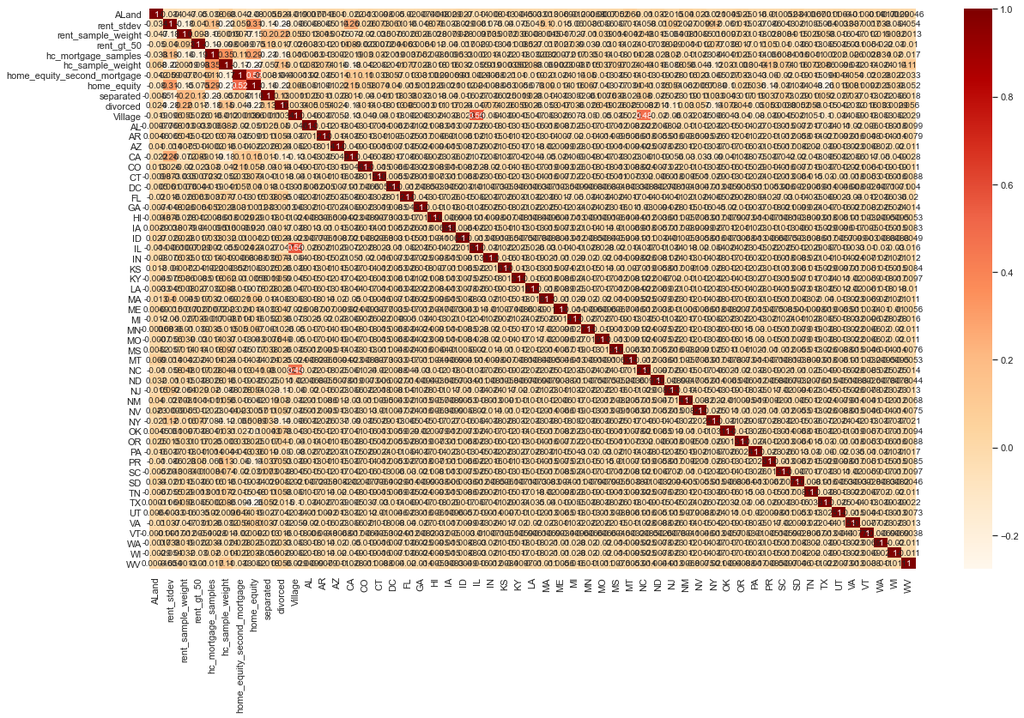

```python
heatmap(20,12,x_new.drop('const',axis=1))
```

> No High Correlation can be seen among the independent variables.

### Residual Analysis

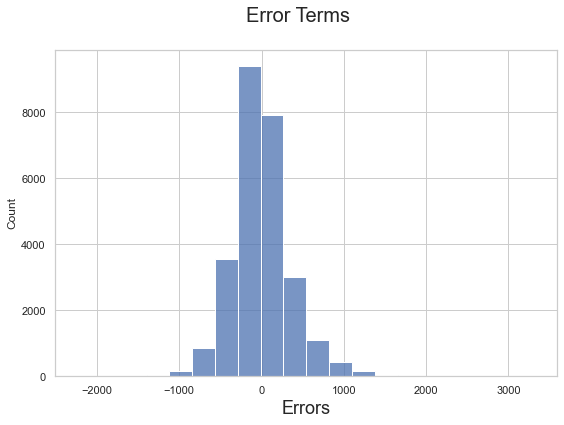

```python
y_train_price = lm_new.predict(x_new)
fig = plt.figure(figsize=(9,6))
sns.histplot((y_train - y_train_price), bins = 20)
fig.suptitle('Error Terms', fontsize = 20)                  # Plot heading
plt.xlabel('Errors', fontsize = 18)
plt.show()
```

> Error terms are distributed around zero which signifies that model prediction is not by chance.

# Making Predictions

```python
df_test.head()
```

|  | lat | lng | ALand | AWater | pop | male_pop | female_pop | rent_mean | rent_median | rent_stdev | rent_sample_weight | rent_samples | rent_gt_10 | rent_gt_15 | rent_gt_20 | rent_gt_25 | rent_gt_30 | rent_gt_35 | rent_gt_40 | rent_gt_50 | universe_samples | used_samples | hi_mean | hi_median | hi_stdev | hi_sample_weight | hi_samples | family_mean | family_median | … |
| --- | --- | --- | --- | --- | --- | --- | --- | --- | --- | --- | --- | --- | --- | --- | --- | --- | --- | --- | --- | --- | --- | --- | --- | --- | --- | --- | --- | --- | --- | --- |
| 258 | 17.97 | -66.61 | 3,946,834.00 | 5093745 | 4688 | 2211 | 2477 | 739.91 | 773.00 | 186.38 | 299.30 | 375.00 | 1.00 | 1.00 | 0.91 | 0.91 | 0.77 | 0.77 | 0.77 | 0.77 | 546 | 319 | 32,024.03 | 23,941.00 | 39,369.65 | 1,527.39 | 1,876.00 | 40,845.84 | 31,971.00 | … |
| 1820 | 17.99 | -67.00 | 58,350,923.00 | 11638620 | 2775 | 1482 | 1293 | 322.09 | 370.00 | 114.74 | 54.00 | 54.00 | 1.00 | 1.00 | 0.72 | 0.72 | 0.36 | 0.36 | 0.00 | 0.00 | 456 | 25 | 16,491.31 | 11,541.00 | 21,924.03 | 860.31 | 1,030.00 | 18,143.80 | 13,337.00 | … |
| 2377 | 18.00 | -65.90 | 1,719,472.00 | 510893 | 1619 | 841 | 778 | 390.41 | 351.00 | 175.32 | 187.00 | 187.00 | 0.89 | 0.73 | 0.67 | 0.57 | 0.48 | 0.35 | 0.29 | 0.21 | 214 | 183 | 32,243.21 | 18,621.00 | 49,395.47 | 467.08 | 582.00 | 39,619.13 | 24,122.00 | … |
| 6492 | 18.00 | -66.64 | 1,352,126.00 | 5489 | 3882 | 1660 | 2222 | 536.13 | 561.00 | 261.69 | 252.53 | 291.00 | 0.86 | 0.86 | 0.80 | 0.71 | 0.60 | 0.41 | 0.37 | 0.26 | 425 | 291 | 29,110.73 | 19,385.00 | 28,481.82 | 1,168.48 | 1,446.00 | 33,874.30 | 26,649.00 | … |
| 9871 | 18.01 | -66.63 | 526,009.00 | 0 | 3509 | 1580 | 1929 | 288.67 | 158.00 | 359.09 | 545.51 | 744.00 | 0.93 | 0.88 | 0.83 | 0.74 | 0.66 | 0.52 | 0.45 | 0.43 | 990 | 579 | 13,305.79 | 8,187.00 | 24,384.75 | 1,066.48 | 1,364.00 | 16,915.91 | 9,560.00 | … |

5 rows × 122 columns

```python
final_features = list(x_new.columns)
final_features.remove('const')
print('The final features: ',final_features)
```

```
The final features:  ['ALand', 'rent_stdev', 'rent_sample_weight', 'rent_gt_50', 'hc_mortgage_samples', 'hc_sample_weight', 'home_equity_second_mortgage', 'home_equity', 'separated', 'divorced', 'Village', 'AL', 'AR', 'AZ', 'CA', 'CO', 'CT', 'DC', 'FL', 'GA', 'HI', 'IA', 'ID', 'IL', 'IN', 'KS', 'KY'…
```

### Using our model to make predictions.

```python
x_test_new = x_test.filter(final_features) # keeping the significant features only
x_test_new = sm.add_constant(x_test_new) # Adding a constant variable
y_pred = lm_new.predict(x_test_new) # Making predictions
```

## Model Evaluation

#### Calculating the R-squared score on the test dataset

```python
from sklearn.metrics import r2_score
r2 = r2_score(y_test, y_pred)
log("R-square calculated for test data is : "+str(r2))
```

> R-square calculated for test data is : 0.6738971786071565

#### Plotting test vs. predicted to understand the spread.

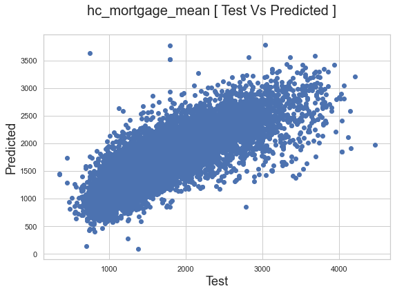

```python
fig = plt.figure(figsize=(9,6))
plt.scatter(y_test,y_pred)
fig.suptitle('hc_mortgage_mean [ Test Vs Predicted ]', fontsize=20)              # Plot heading
plt.xlabel('Test', fontsize=18)                          # X-label
plt.ylabel('Predicted', fontsize=18)                          # Y-label
plt.show()
```

### **Test if predicted variable is normally distributed**

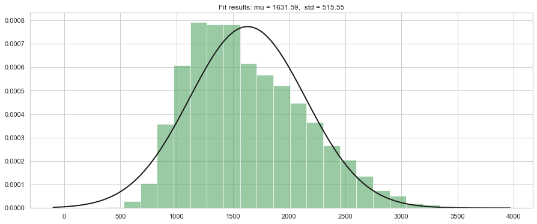

```python
data = y_pred.values.reshape(-1,1)
import numpy as np
from scipy.stats import norm
import matplotlib.pyplot as plt

# Fitting a normal distribution to the data:
mu, std = norm.fit(data)

# Plot the histogram.
plt.figure(figsize = (15,6))
plt.hist(data, bins=25, density=True, alpha=0.6, color='g')

# Plot the PDF.
xmin, xmax = plt.xlim()
x = np.linspace(xmin, xmax, 100)
p = norm.pdf(x, mu, std)
plt.plot(x, p, 'k', linewidth=2)
title = "Fit results: mu = %.2f,  std = %.2f" % (mu, std)
plt.title(title)

plt.show()
```

> Our predicted values are almost normally distributed

#### Mean and standard error of the predictor

```python
from numpy import mean
from numpy import std
print('mean=%.3f stdv=%.3f' % (mean(data), std(data)))
```

```
mean=1631.585 stdv=515.550
```

# Final Model Summary

```python
print(lm_new.summary())
```

```
                            OLS Regression Results
==============================================================================
Dep. Variable:       hc_mortgage_mean   R-squared:                       0.673
Model:                            OLS   Adj. R-squared:                  0.672
Method:                 Least Squares   F-statistic:                     998.8
Date:                Tue, 20 Jul 2021   Prob (F-statistic):               0.00
Time:                        17:45:01   Log-Likelihood:            -1.9512e+05
No. Observations:               26748   AIC:                         3.904e+05
Df Residuals:                   26692   BIC:                         3.908e+05
Df Model:                          55
Covariance Type:            nonrobust
===============================================================================================
                                  coef    std err          t      P>|t|      [0.025      0.975]
-----------------------------------------------------------------------------------------------
const                        1450.3358     16.723     86.728      0.000    1417.558    1483.113
ALand                       -5.009e-09   1.73e-09     -2.896      0.004    -8.4e-09   -1.62e-09
rent_stdev                      1.1232      0.014     80.773      0.000       1.096       1.150
rent_sample_weight             -0.1767      0.009    -20.050      0.000      -0.194      -0.159
rent_gt_50                   -262.8084     16.799    -15.644      0.000    -295.735    -229.881
hc_mortgage_samples             0.1136      0.006     19.130      0.000       0.102       0.125
hc_sample_weight               -0.5225      0.015    -35.304      0.000      -0.551      -0.493
home_equity_second_mortgage -1689.7764     84.461    -20.007      0.000   -1855.325   -1524.228
home_equity                  2186.5698     45.256     48.316      0.000    2097.866    2275.273
separated                   -1882.0848    115.460    -16.301      0.000   -2108.392   -1655.777
divorced                    -1586.2471     51.327    -30.905      0.000   -1686.851   -1485.643
Village                      -318.8204     15.723    -20.277      0.000    -349.639    -288.002
AL                           -214.6807     21.594     -9.942      0.000    -257.006    -172.355
AR                           -192.2907     25.363     -7.581      0.000    -242.004    -142.577
AZ                           -221.6381     19.659    -11.274      0.000    -260.170    -183.106
CA                            234.1532     13.704     17.087      0.000     207.293     261.014
CO                           -159.4485     20.396     -7.817      0.000    -199.427    -119.471
CT                            178.9152     23.202      7.711      0.000     133.438     224.392
DC                            154.6567     45.644      3.388      0.001      65.191     244.122
FL                            -76.1463     15.074     -5.051      0.000    -105.693     -46.600
GA                           -181.7851     17.691    -10.276      0.000    -216.459    -147.111
HI                            302.0117     35.017      8.625      0.000     233.376     370.648
IA                           -352.7280     24.343    -14.490      0.000    -400.442    -305.014
ID                           -271.6361     37.557     -7.233      0.000    -345.250    -198.022
IL                            271.6465     14.806     18.348      0.000     242.627     300.666
IN                           -408.8567     19.317    -21.166      0.000    -446.719    -370.995
```

[output cut: 26 more lines]

```
VT                           -128.9856     46.878     -2.751      0.006    -220.870     -37.102
WA                            -38.5858     19.463     -1.983      0.047     -76.734      -0.438
WI                           -208.7257     19.619    -10.639      0.000    -247.180    -170.272
WV                           -255.9498     30.476     -8.398      0.000    -315.685    -196.215
==============================================================================
Omnibus:                     4214.543   Durbin-Watson:                   1.843
Prob(Omnibus):                  0.000   Jarque-Bera (JB):            15939.972
Skew:                           0.760   Prob(JB):                         0.00
Kurtosis:                       6.463   Cond. No.                     6.90e+10
==============================================================================

Notes:
[1] Standard Errors assume that the covariance matrix of the errors is correctly specified.
[2] The condition number is large, 6.9e+10. This might indicate that there are
strong multicollinearity or other numerical problems.
```

> R-sqaured for train and test data are 67% each which means 67% variability is explained and no over and underfitting.

> p-values for the coefficients are less than the significance level of 5%, which means all the predictors are statistically significant.

> As per final model attributes which are best suited for predicting **The mean Monthly Mortgage and Owner Costs** are:

> ```
> 1.  The Square area of land<br>
> 2.  The standard deviation of the gross rent<br>
> 3.  The sum of gross rent weight used in calculations.<br>
> 4.  The empirical distribution value that an individual’s rent will be greater than 50% of their household income in the past 12 months.<br>
> 5.  The number of samples used in the statistical calculations<br>
> 6.  The samples used in the calculation of the Monthly Owner Costs statistics.<br>
> 7.  % of houses with a second mortgage and home equity loan<br>
> 8.  % of houses with a home equity loan<br>
> 9.  Marital Status<br>
> 10. Type of Location (Village)<br>
> 11. The States which have significant effect on mean Monthly Mortgage and Owner Costs are AL, AR, AZ, CA, CO, CT, DC, FL, GA, HI, IA, ID, IL, IN, KS, KY, LA, MA, ME, MI, MN, MO, MS, MT, NC, ND, NJ, NM, NV, NY, OK, OR, PA, PR, SC, SD, TN, TX, UT, VA, VT, WA, WI, WV<br>
> ```